# PCA final: 970 lotes, 8 variables

Revisión según la sustentación · Coffee Quality Institute

Juan Sebastián Guayazán · Esteban Valente · Diego Nocua

20 de noviembre de 2026

**En resumen.** De 1.070 lotes se retiran 100 atípicos multivariados (9,3 %) y quedan 970. Con ellos, CP1 explica 69,3 % de la variación (calidad sensorial general), CP2 11,6 % (altitud) y juntas 80,9 % (IC bootstrap 79,3–82,5 %). La nube de lotes es continua: el PCA resume la calidad, no separa grupos.

# Qué responde este informe

**Pregunta:** ¿se pueden resumir ocho medidas de un lote de café (siete atributos sensoriales y la altitud) en pocas dimensiones sin perder lo esencial, y qué tan confiable es ese resumen?

**Cómo está organizado.** Cada sección sigue el mismo esquema: *qué hacemos y por qué*, *el resultado* (tabla o figura) y *cómo se lee*. El código está oculto; se despliega con el botón «Code» de cada bloque o el de la parte superior.

| Sección | Qué se hace | Qué se concluye |
| --- | --- | --- |
| 1 | Datos y depuración 1.070 → 970 | 100 lotes atípicos retirados |
| 2 | Simetría y tipo de diagrama de cajas | Caja robusta (MAD) para los atributos sensoriales |
| 3 | Yeo-Johnson solo si hace falta | En los 970 lotes ninguna variable lo necesita |
| 4 | Supuestos del PCA | Estandarizar es necesario; quedan atípicos leves |
| 5 | Codo con intervalos de confianza | CP1 + CP2 = 80,9 % |
| 6 | Dispersión de los lotes | Una sola nube continua |
| 7 | Cargas y biplot | CP1 = calidad general; CP2 = altitud |
| 8 | t-SNE y UMAP | Exploratorios: no revelan grupos |

# 1. Datos y depuración: de 1.070 a 970 lotes

**Qué hacemos.** Partimos de la base limpia del Coffee Quality Institute, conservamos los lotes con altitud registrada y menor o igual a 3.000 m, y trabajamos con ocho variables: siete atributos sensoriales (Aroma, Sabor, Retrogusto, Acidez, Cuerpo, Balance y Puntaje del catador) y la altitud. Luego se retiran los atípicos multivariados con la distancia de Mahalanobis, **una sola vez**, con el umbral χ² al 97,5 % y 8 grados de libertad. La cadena completa está en depuración.

```r
d <- read.csv("../data/arabica_data_cleaned.csv")
vars14 <- c("Aroma","Flavor","Aftertaste","Acidity","Body","Balance","Uniformity","Clean.Cup","Sweetness","Cupper.Points","Moisture","Category.One.Defects","Category.Two.Defects","altitude_mean_meters")
b <- d[!is.na(d$altitude_mean_meters) & d$altitude_mean_meters > 0 & d$altitude_mean_meters <= 3000, ]
b <- b[complete.cases(b[, vars14]), ]
meta <- b[, c("Processing.Method", "Color")]
X8 <- b[, c("Aroma","Flavor","Aftertaste","Acidity","Body","Balance","Cupper.Points","altitude_mean_meters")]
names(X8) <- c("Aroma","Sabor","Retrogusto","Acidez","Cuerpo","Balance","Puntaje.Catador","Altitud")
base <- readRDS("../datos/base_1070.rds")
lim <- qchisq(0.975, 8)
# Una sola pasada de Mahalanobis sobre la base de 1.070 transformada y estandarizada.
# Corrección: el código anterior usaba rowSums((pre$x / pre$sdev)^2), que recicla sdev por filas
# y marcaba 404 lotes; la distancia correcta marca 100 (ver depuracion.Rmd, sección 3).
md1070 <- mahalanobis(base$Z, colMeans(base$Z), cov(base$Z))
out1 <- md1070 > lim
keep_idx <- which(!out1)
# Matriz final oficial: 970 lotes. Yeo-Johnson se re-evalúa sobre los 970 con la misma regla (|asimetría| > 1)
fin <- readRDS("../datos/datos_final_970.rds")
F970 <- fin$datos_limpio
names(F970) <- names(X8)
stopifnot(isTRUE(all.equal(as.matrix(fin$datos_originales), as.matrix(X8[keep_idx, ]), check.attributes = FALSE)))
meta970 <- meta[keep_idx, ]
raw970 <- X8[keep_idx, ]
add("n inicial 1070 = ", nrow(X8), "; atipicos (una pasada) = ", sum(out1), "; n final = ", nrow(F970))

etapas <- data.frame(
  Etapa = c("Base original del CQI", "Tras filtrar por altitud (0–3.000 m) y registros completos",
            "Tras retirar atípicos multivariados (Mahalanobis, una pasada)"),
  Lotes = c(nrow(d), nrow(X8), nrow(F970)),
  Retirados = c(NA, nrow(d) - nrow(X8), sum(out1)))
tabla(etapas, align = "lrr", caption = "Cadena de depuración")
```

Cadena de depuración

| Etapa | Lotes | Retirados |
| --- | --- | --- |
| Base original del CQI | 1.311 | — |
| Tras filtrar por altitud (0–3.000 m) y registros completos | 1.070 | 241 |
| Tras retirar atípicos multivariados (Mahalanobis, una pasada) | 970 | 100 |

**Cómo se lee.** Se retiran 241 lotes por no tener altitud registrada o tener una mayor a 3.000 m, y luego 100 lotes (9,3 %) por tener combinaciones de puntajes muy poco habituales; quedan **970**. El umbral de Mahalanobis es 17,53: si los datos fueran normales, solo el 2,5 % de los lotes lo superaría.

> **Corrección de cálculo.** Una versión anterior dividía los scores entre la desviación equivocada (R recicla el vector por filas, no por columnas) y marcaba 404 lotes en lugar de 100. El detalle está en depuración, sección 3.

# 2. Simetría y diagrama de cajas

**Qué hacemos y por qué.** Un diagrama de cajas clásico marca como «atípico» todo lo que sale de 1,5 veces el rango intercuartílico, y eso presupone una distribución simétrica. Antes de decidir qué atípicos mirar, medimos la simetría con el **medcouple** (MC), una medida robusta que va de −1 a 1. La regla es:

- si |MC| ≤ 0,1 la variable se trata como simétrica y se usa la caja **robusta** (mediana ± 3 MAD);
- si |MC| > 0,1 se usa la caja **ajustada** de Hubert y Vandervieren, que corrige los bigotes por la asimetría.

```r
mc <- sapply(X8, function(x) mc(x))
sk <- sapply(X8, function(x) mean((x - mean(x))^3) / sd(x)^3)
# Regla literal de la recomendación: si la variable es simétrica (|MC| <= 0.1) se usa
# boxplot robusto (mediana y MAD); si es asimétrica, boxplot ajustado (Hubert-Vandervieren).
tipo <- ifelse(abs(mc) > 0.1, "ajustado (asimetrico)", "robusto MAD (simetrico)")
n_cl <- sapply(X8, function(x) length(boxplot.stats(x)$out))
n_mad <- sapply(X8, function(x) sum(abs(x - median(x)) > 3 * 1.4826 * mad(x)))
n_ad <- sapply(X8, function(x) sum(x < adjboxStats(x)$stats[1] | x > adjboxStats(x)$stats[5]))
n_usado <- ifelse(abs(mc) > 0.1, n_ad, n_mad)
tab_sim <- data.frame(variable = names(X8), medcouple = round(mc, 3), asimetria = round(sk, 3),
                      boxplot = tipo, atipicos_clasico = n_cl, atipicos_robusto_usado = n_usado)
write.csv(tab_sim, "figuras/revision_profesor/tabla_simetria_boxplot.csv", row.names = FALSE)
add("\n== Simetria (medcouple) y tipo de diagrama de cajas ==")
add(paste(capture.output(print(tab_sim, row.names = FALSE)), collapse = "\n"))

dibujar_cajas <- function() {
  par(mfrow = c(2, 4), mar = c(4, 4, 3, 1), cex.main = 1.2)
  for (v in names(X8)) {
    x <- X8[[v]]
    boxplot(x, main = paste0(v, " (MC=", round(mc[v], 2), ")"), col = if (abs(mc[v]) > 0.1) "#f5cba7" else "#aed6f1", outcol = "#c0392b")
    if (abs(mc[v]) > 0.1) {
      st <- adjboxStats(x)$stats
    } else {
      st <- median(x) + c(-3, 3) * 1.4826 * mad(x)
    }
    abline(h = st[c(1, length(st))], lty = 3, col = "#117a65")
  }
}
png("figuras/revision_profesor/boxplot_clasico_vs_ajustado.png", width = 2000, height = 1100, res = 180)
dibujar_cajas(); invisible(dev.off())

nombres_tab <- c("Variable", "Medcouple", "Asimetría clásica", "Caja usada", "Atípicos (caja clásica)", "Atípicos (caja usada)")
tabla(setNames(tab_sim, nombres_tab), align = "lrrlrr", caption = "Simetría y tipo de caja (1.070 lotes)")
```

Simetría y tipo de caja (1.070 lotes)

| Variable | Medcouple | Asimetría clásica | Caja usada | Atípicos (caja clásica) | Atípicos (caja usada) |
| --- | --- | --- | --- | --- | --- |
| Aroma | 0,030 | -7,218 | robusto MAD (simetrico) | 55 | 4 |
| Sabor | 0,000 | -6,041 | robusto MAD (simetrico) | 31 | 1 |
| Retrogusto | -0,059 | -5,636 | robusto MAD (simetrico) | 63 | 9 |
| Acidez | 0,000 | -6,902 | robusto MAD (simetrico) | 19 | 4 |
| Cuerpo | 0,000 | -8,231 | robusto MAD (simetrico) | 23 | 2 |
| Balance | 0,000 | -5,405 | robusto MAD (simetrico) | 35 | 7 |
| Puntaje.Catador | 0,000 | -3,838 | robusto MAD (simetrico) | 25 | 6 |
| Altitud | 0,112 | -0,827 | ajustado (asimetrico) | 47 | 73 |

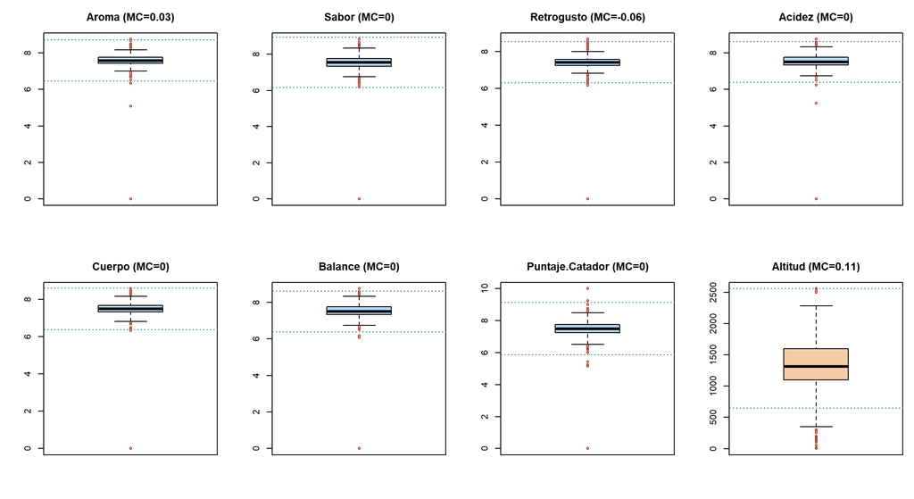

Cajas por variable. Azul: caja robusta (simétrica); naranja: caja ajustada (asimétrica); puntos rojos: atípicos de la caja clásica; líneas verdes: límites usados.

```r
dibujar_cajas()
```

**Cómo se lee.** Los siete atributos sensoriales tienen medcouple cercano a 0: el grueso de los lotes es simétrico y se usa la caja robusta. Aun así su asimetría clásica es muy negativa (de −3,8 a −8,2): la producen unos pocos lotes con puntajes extremadamente bajos, no la forma general de la distribución. Por eso la caja clásica marca entre 19 y 63 atípicos por variable, mientras la caja robusta marca solo entre 1 y 9. La **altitud** (MC = 0,112) está justo sobre el umbral y se trata con la caja ajustada.

# 3. Yeo-Johnson solo donde hace falta

**Qué hacemos y por qué.** La transformación Yeo-Johnson corrige asimetrías fuertes, pero transformar variables que ya son razonablemente simétricas solo complica la interpretación. Por eso se aplica **únicamente a las variables con |asimetría| > 1**.

```r
add("\n== Yeo-Johnson: solo variables con |asimetria| > 1 en la base de 1.070 ==")
add("Variables transformadas: ", paste(names(base$lambdas), collapse = ", "))
add("Lambdas estimadas sobre 1.070 (PCA preliminar): ", paste(round(base$lambdas, 3), collapse = ", "))
add("Lambdas re-estimadas sobre 970 (PCA final): ", if (length(fin$lambdas)) paste(round(fin$lambdas, 3), collapse = ", ") else "ninguna; sin los 100 atipicos ninguna variable tiene |asimetria| > 1, asi que no se transforma")
skew_970_raw <- sapply(raw970, function(x) mean((x - mean(x))^3) / sd(x)^3)
skew_970_trans <- sapply(F970, function(x) mean((x - mean(x))^3) / sd(x)^3)
add("Asimetria antes (raw, 970): ", paste(names(skew_970_raw), round(skew_970_raw, 2), collapse = " | "))
add("Asimetria despues (transformada, 970): ", paste(names(skew_970_trans), round(skew_970_trans, 2), collapse = " | "))

tab_yj <- data.frame(
  Variable = names(X8),
  `Asimetría en 1.070 lotes` = round(sk, 2),
  `¿Se transformó en la base de 1.070?` = ifelse(names(X8) %in% names(base$lambdas), "Sí", "No"),
  `Asimetría en los 970 lotes finales` = round(skew_970_trans, 2),
  `¿Supera 1 en valor absoluto?` = ifelse(abs(skew_970_trans) > 1, "Sí", "No"),
  check.names = FALSE)
tabla(tab_yj, align = "lrcrc", caption = "Asimetría antes y después de retirar los atípicos")
```

Asimetría antes y después de retirar los atípicos

| Variable | Asimetría en 1.070 lotes | ¿Se transformó en la base de 1.070? | Asimetría en los 970 lotes finales | ¿Supera 1 en valor absoluto? |
| --- | --- | --- | --- | --- |
| Aroma | -7,22 | Sí | -0,24 | No |
| Sabor | -6,04 | Sí | -0,45 | No |
| Retrogusto | -5,64 | Sí | -0,47 | No |
| Acidez | -6,90 | Sí | -0,02 | No |
| Cuerpo | -8,23 | Sí | -0,17 | No |
| Balance | -5,41 | Sí | -0,35 | No |
| Puntaje.Catador | -3,84 | Sí | -0,32 | No |
| Altitud | -0,83 | No | -0,69 | No |

**Cómo se lee.** En la base de 1.070 lotes los siete atributos sensoriales superaban |asimetría| 1, así que allí sí se aplicó Yeo-Johnson (λ entre 2,2 y 3,6). Pero al retirar los 100 atípicos la asimetría de **todas** las variables cae por debajo de 1 (la mayor es la altitud, −0,69). Conclusión: el PCA final de 970 lotes **no usa Yeo-Johnson**; solo estandariza.

# 4. Supuestos del PCA

**Qué hacemos y por qué.** Dos supuestos prácticos importan: (1) las variables deben estar en una escala comparable y centradas, y (2) no deben quedar atípicos muy fuertes que dominen las componentes.

```r
Zf <- scale(F970, center = TRUE, scale = TRUE)
add("\n== Supuestos del PCA (970 lotes) ==")
add("prcomp centra internamente (center = TRUE); Altitud tiene media ~", round(mean(F970[, 8])), " m antes de centrar")
md970 <- mahalanobis(Zf, colMeans(Zf), cov(Zf))
add("Atipicos multivariados restantes (d2 > chi2 0.975, 8 g.l.): ", sum(md970 > lim), " de ", nrow(Zf), " (esperados por azar ~", round(0.025 * nrow(Zf)), ")")

resumen_escala <- data.frame(Variable = names(F970), Media = round(colMeans(F970), 2), `Desviación estándar` = round(apply(F970, 2, sd), 2), check.names = FALSE)
tabla(resumen_escala, align = "lrr", caption = "Escala original de cada variable (970 lotes)")
```

Escala original de cada variable (970 lotes)

| Variable | Media | Desviación estándar |
| --- | --- | --- |
| Aroma | 7,56 | 0,27 |
| Sabor | 7,51 | 0,30 |
| Retrogusto | 7,39 | 0,31 |
| Acidez | 7,52 | 0,28 |
| Cuerpo | 7,49 | 0,25 |
| Balance | 7,48 | 0,30 |
| Puntaje.Catador | 7,47 | 0,35 |
| Altitud | 1.321,18 | 383,41 |

**Cómo se lee.**

- **Estandarizar es necesario.** La altitud promedia unos 1.321 m con desviación de cientos de metros, mientras los puntajes se mueven en una escala de 0 a 10. Sin estandarizar, la altitud dominaría el PCA solo por su escala. Estandarizar centra cada variable en 0 y la divide entre su desviación estándar.
- **Atípicos restantes.** Al repetir la regla sobre los 970 lotes aparecen 63 marcados (por azar se esperarían unos 24). No se retiran: al quitar los extremos la nube se encoge y otros lotes pasan a parecer lejanos, así que el filtro no terminaría nunca. Es una limitación que se declara.

# 5. PCA final y gráfico del codo con intervalos de confianza

**Qué hacemos y por qué.** Ajustamos el PCA sobre los 970 lotes estandarizados. Para saber qué tan estable es la varianza explicada, repetimos el cálculo en 2.000 remuestras (bootstrap) y tomamos el rango central del 95 %.

```r
pca <- prcomp(F970, center = TRUE, scale. = TRUE)
prop <- pca$sdev^2 / sum(pca$sdev^2)
B <- 2000
boot_prop <- matrix(NA, B, 8)
for (i in seq_len(B)) {
  idx <- sample(nrow(F970), replace = TRUE)
  s <- prcomp(F970[idx, ], center = TRUE, scale. = TRUE)$sdev^2
  boot_prop[i, ] <- s / sum(s)
}
ci <- t(apply(boot_prop, 2, quantile, c(0.025, 0.975)))
tab_var <- data.frame(componente = paste0("CP", 1:8), varianza = round(prop * 100, 1),
                      ic_inf = round(ci[, 1] * 100, 1), ic_sup = round(ci[, 2] * 100, 1))
tab_var$acum_CP1_CP2 <- round(sum(prop[1:2]) * 100, 1)
write.csv(tab_var, "figuras/revision_profesor/tabla_varianza_IC.csv", row.names = FALSE)
add("\n== Varianza por componente con IC 95 % (bootstrap B = 2000) ==")
add(paste(capture.output(print(tab_var, row.names = FALSE)), collapse = "\n"))
ic_acum <- quantile(rowSums(boot_prop[, 1:2]), c(0.025, 0.975)) * 100
add("IC acumulado CP1+CP2: ", paste(round(ic_acum, 1), collapse = " a "), " %")

dibujar_codo <- function() {
  par(mar = c(4.5, 4.5, 3, 1), cex.main = 1.3, cex.lab = 1.2, cex.axis = 1.1)
  bp <- barplot(prop[1:6] * 100, names.arg = paste0("CP", 1:6), col = "#1f4e79", ylim = c(0, 65), ylab = "Varianza explicada (%)", main = "Codo con IC 95 % (bootstrap)")
  arrows(bp, ci[1:6, 1] * 100, bp, ci[1:6, 2] * 100, angle = 90, code = 3, length = 0.05, col = "#c0392b")
  text(bp, prop[1:6] * 100 + 3, paste0(round(prop[1:6] * 100, 1), "%"))
}
png("figuras/revision_profesor/codo_IC.png", width = 1800, height = 1100, res = 180)
dibujar_codo(); invisible(dev.off())

tabla(data.frame(Componente = tab_var$componente, `Varianza (%)` = tab_var$varianza,
                 `IC 95 % inferior` = tab_var$ic_inf, `IC 95 % superior` = tab_var$ic_sup,
                 `Valor propio` = round(pca$sdev^2, 2), check.names = FALSE),
      align = "lrrrr", caption = "Varianza explicada por componente")
```

Varianza explicada por componente

| Componente | Varianza (%) | IC 95 % inferior | IC 95 % superior | Valor propio |
| --- | --- | --- | --- | --- |
| CP1 | 69,3 | 67,5 | 70,9 | 5,54 |
| CP2 | 11,6 | 11,2 | 12,0 | 0,93 |
| CP3 | 5,3 | 4,8 | 6,0 | 0,42 |
| CP4 | 4,1 | 3,7 | 4,6 | 0,33 |
| CP5 | 3,8 | 3,3 | 4,1 | 0,30 |
| CP6 | 2,4 | 2,1 | 2,7 | 0,19 |
| CP7 | 1,9 | 1,7 | 2,2 | 0,15 |
| CP8 | 1,6 | 1,3 | 1,7 | 0,13 |

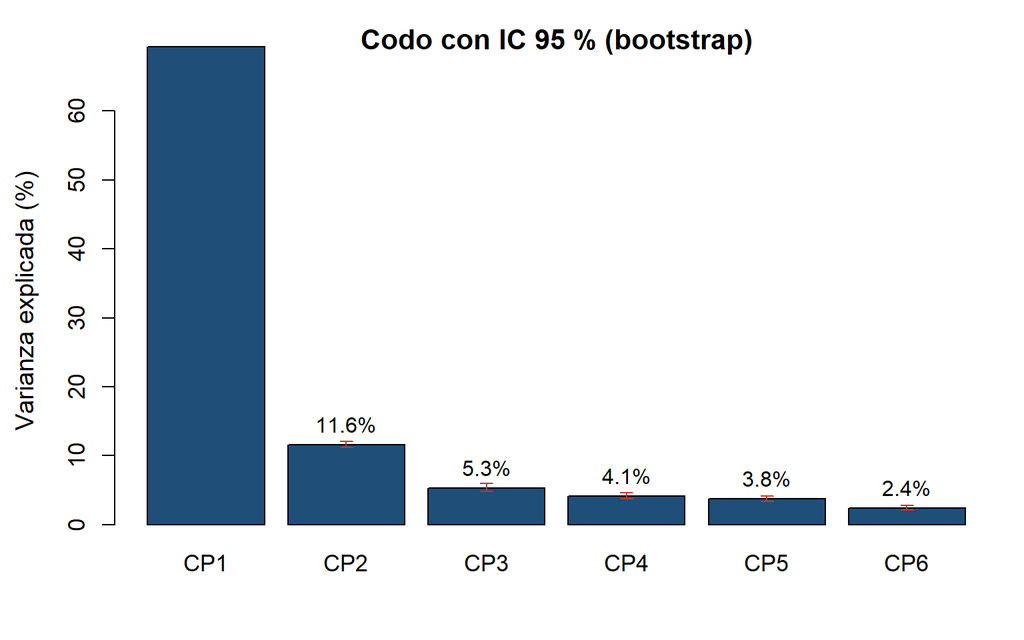

Varianza explicada por cada componente, con su intervalo de confianza bootstrap del 95 % (barras rojas).

```r
dibujar_codo()
```

**Cómo se lee.**

- **CP1 explica 69,3 %** (IC 67,5–70,9 %) y **CP2 11,6 %** (IC 11,2–12,0 %). Juntas: **80,9 %** (IC 79,3–82,5 %).
- Los intervalos son estrechos: el resumen es estable y no depende de la muestra particular.
- Hay un **codo claro después de CP2**: cada componente siguiente aporta menos de 6 %.
- **Criterio de Kaiser** (conservar componentes con valor propio mayor que 1): CP1 pasa con holgura; CP2 queda en 0,93, casi 1. La conservamos porque el codo la respalda y tiene una interpretación clara (altitud). CP3 queda por debajo (0,42).

# 6. Dispersión de los lotes en CP1 y CP2 (antes de ver las cargas)

**Qué hacemos y por qué.** Antes de interpretar los pesos de cada variable, miramos dónde caen los lotes en las dos primeras componentes. Cada punto es un lote; el color es su método de proceso. Si hubiera grupos naturales, se verían como nubes separadas.

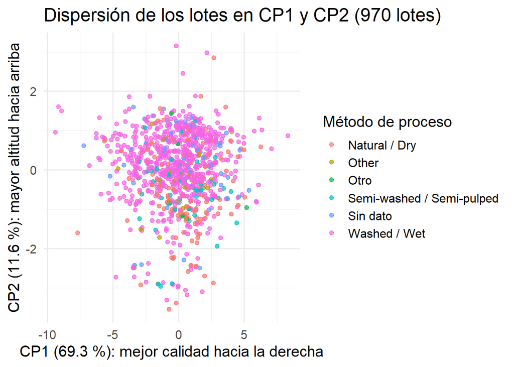

```r
sc <- data.frame(CP1 = pca$x[, 1], CP2 = pca$x[, 2], CP3 = pca$x[, 3], Proceso = meta970$Processing.Method)
sc$Proceso[is.na(sc$Proceso) | sc$Proceso == ""] <- "Sin dato"
top <- names(sort(table(sc$Proceso), decreasing = TRUE))[1:5]
sc$Proceso[!(sc$Proceso %in% top)] <- "Otro"
p_sc <- ggplot(sc, aes(-CP1, -CP2, color = Proceso)) + geom_point(alpha = 0.7, size = 1.6) +
  labs(title = "Dispersión de los lotes en CP1 y CP2 (970 lotes)", x = sprintf("CP1 (%.1f %%): mejor calidad hacia la derecha", prop[1] * 100), y = sprintf("CP2 (%.1f %%): mayor altitud hacia arriba", prop[2] * 100), color = "Método de proceso") +
  theme_minimal(base_size = 15)
ggsave("figuras/revision_profesor/dispersion_CP1_CP2.png", p_sc, width = 8, height = 6, dpi = 200)
p_sc
```

**Cómo se lee.**

- **Hacia la derecha** (CP1 alto) mejora la calidad en taza; **hacia arriba** (CP2 alto) sube la altitud. El 0 de cada eje es el lote promedio. (El signo de una componente en `prcomp` es arbitrario. Aquí se invierte el de CP1 y CP2 solo para que la figura se lea así; por eso las cargas de la sección 7 aparecen con signo negativo.)
- La nube es **continua**: no hay grupos separados, ni siquiera al colorear por método de proceso.
- Es más ancha que alta porque la calidad explica mucha más variación que la altitud.
- Las franjas de puntos en la parte baja son lotes con altitud mal digitada en la base original (1, 12 o 13 m): afectan sobre todo a CP2.

# 7. Cargas de CP1–CP3 y biplot

**Qué hacemos y por qué.** Las cargas dicen cuánto pesa cada variable en cada componente: cuanto más lejos de 0, más contribuye. Nos permiten ponerle nombre a las componentes.

```r
L <- round(pca$rotation[, 1:3], 2)
write.csv(L, "figuras/revision_profesor/cargas_CP1_CP3.csv")
add("\n== Cargas CP1-CP3 ==")
add(paste(capture.output(print(L)), collapse = "\n"))
dibujar_biplot <- function() {
  biplot(pca, choices = 1:2, cex = c(0.4, 1), col = c("grey40", "#c0392b"), xlab = sprintf("CP1 (%.1f %%)", prop[1] * 100), ylab = sprintf("CP2 (%.1f %%)", prop[2] * 100), main = "Biplot (970 lotes)")
}
png("figuras/revision_profesor/biplot.png", width = 1800, height = 1400, res = 180)
dibujar_biplot(); invisible(dev.off())

tabla(data.frame(Variable = rownames(L), CP1 = L[, 1], CP2 = L[, 2], CP3 = L[, 3]), align = "lrrr", caption = "Cargas de las tres primeras componentes")
```

Cargas de las tres primeras componentes

| Variable | CP1 | CP2 | CP3 |
| --- | --- | --- | --- |
| Aroma | -0,35 | -0,02 | -0,64 |
| Sabor | -0,39 | 0,07 | -0,21 |
| Retrogusto | -0,39 | 0,10 | 0,02 |
| Acidez | -0,36 | -0,03 | -0,15 |
| Cuerpo | -0,35 | 0,09 | 0,68 |
| Balance | -0,38 | 0,05 | 0,23 |
| Puntaje.Catador | -0,39 | 0,07 | 0,04 |
| Altitud | -0,13 | -0,98 | 0,08 |

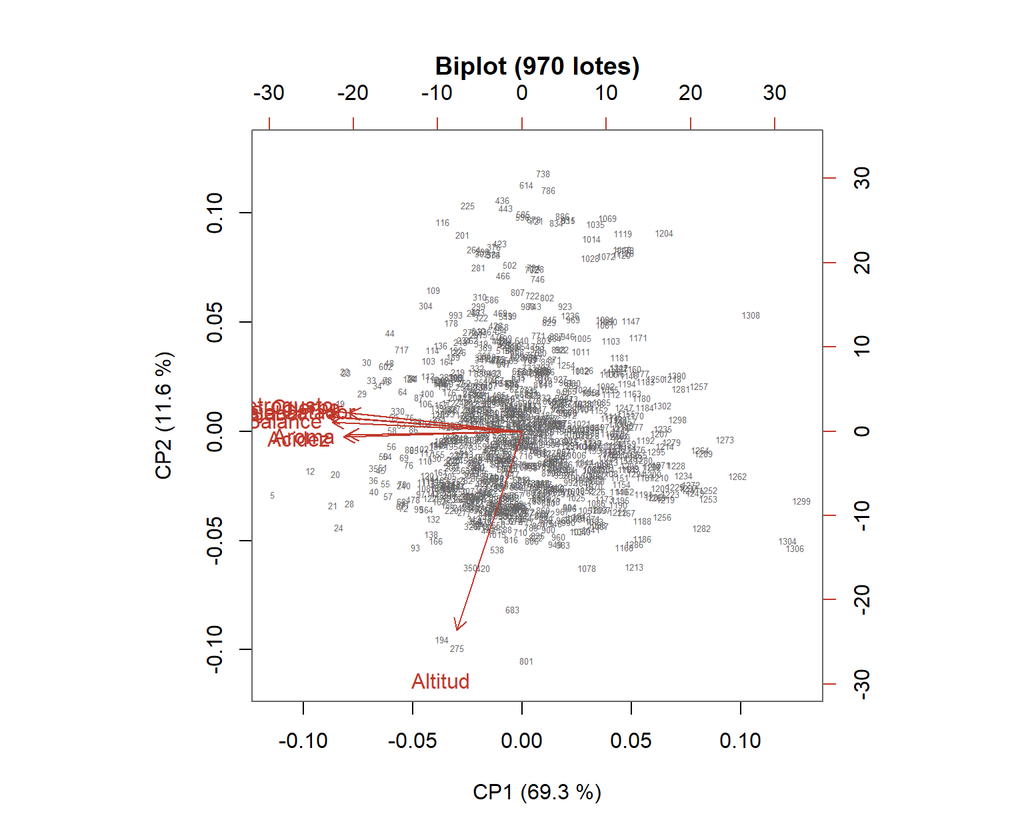

Biplot: puntos grises = lotes; flechas rojas = variables. Flechas juntas indican variables que se mueven juntas.

```r
dibujar_biplot()
```

**Cómo se lee.**

- **CP1 = calidad sensorial general.** Los siete atributos pesan casi lo mismo (entre −0,35 y −0,39; el signo es arbitrario) y la altitud casi nada. Un lote con CP1 alto tiene buenos puntajes en todo a la vez.
- **CP2 = altitud.** La altitud pesa −0,98 y los atributos sensoriales casi 0: la altitud va por su lado y no por el de la calidad.
- **CP3 = contraste pequeño entre aroma y cuerpo.** Aroma pesa −0,64 y Cuerpo +0,68. Explica solo 5,3 % y su valor propio está bajo 1, así que no lo interpretamos más allá de eso.
- En el biplot, las flechas de los siete atributos apuntan casi en la misma dirección (están muy correlacionados; hacia la izquierda porque el signo es arbitrario) y la de altitud es casi perpendicular a ellas.

# 8. t-SNE y UMAP exploratorios

**Qué hacemos y por qué.** Son dos métodos no lineales que buscan conservar vecindades entre lotes. Los usamos solo como mirada exploratoria complementaria al PCA: **sus ejes no se interpretan** y la forma depende de parámetros (perplejidad 30 en t-SNE; 15 vecinos en UMAP).

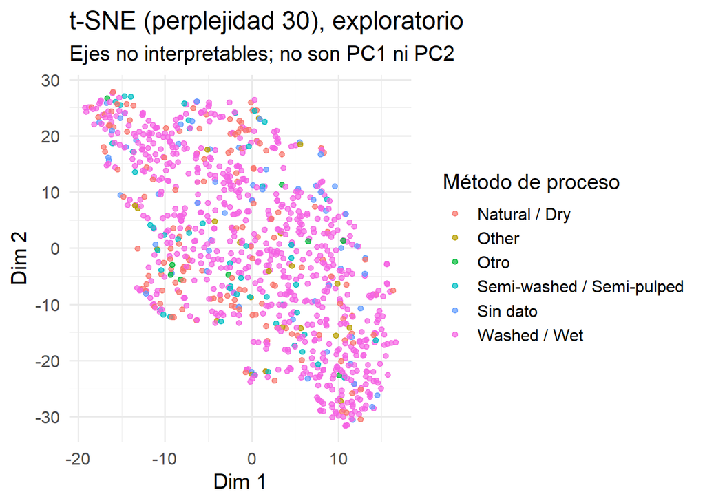

```r
set.seed(2026)
ts <- Rtsne(Zf, perplexity = 30, check_duplicates = FALSE, verbose = FALSE, max_iter = 1000)
dt <- data.frame(X = ts$Y[, 1], Y = ts$Y[, 2], Proceso = sc$Proceso)
p_ts <- ggplot(dt, aes(X, Y, color = Proceso)) + geom_point(alpha = 0.7, size = 1.4) +
  labs(title = "t-SNE (perplejidad 30), exploratorio", subtitle = "Ejes no interpretables; no son PC1 ni PC2", x = "Dim 1", y = "Dim 2", color = "Método de proceso") + theme_minimal(base_size = 15)
ggsave("figuras/revision_profesor/tsne_perp30.png", p_ts, width = 8, height = 6, dpi = 200)
set.seed(2026)
um <- umap(Zf, n_neighbors = 15, min_dist = 0.1, n_components = 2)
du <- data.frame(X = um[, 1], Y = um[, 2], Proceso = sc$Proceso)
p_um <- ggplot(du, aes(X, Y, color = Proceso)) + geom_point(alpha = 0.7, size = 1.4) +
  labs(title = "UMAP (15 vecinos), exploratorio", subtitle = "Ejes no interpretables; la estructura depende de los parámetros", x = "UMAP1", y = "UMAP2", color = "Método de proceso") + theme_minimal(base_size = 15)
ggsave("figuras/revision_profesor/umap_vecinos15.png", p_um, width = 8, height = 6, dpi = 200)
add("\nt-SNE: perplejidad 30, semilla 2026. UMAP: 15 vecinos, min_dist 0.1, semilla 2026. Exploratorios.")
writeLines(out_txt, "resultados_revision_profesor.txt")
p_ts
```

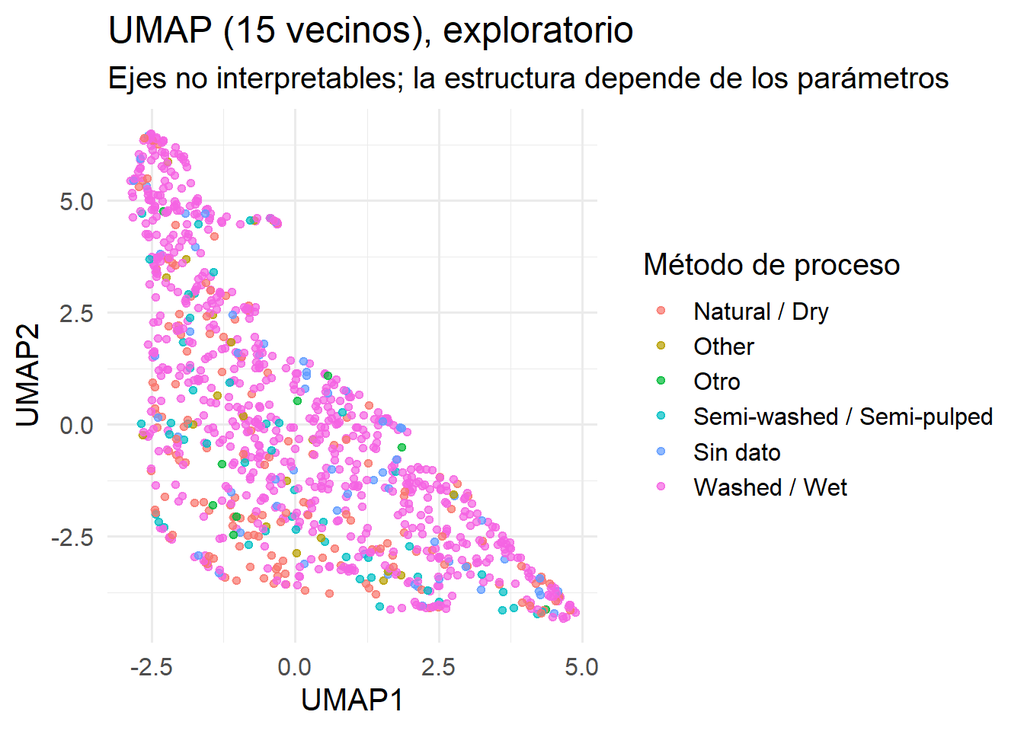

```r
p_um
```

**Cómo se lee.** Ninguno de los dos mapas muestra grupos claramente separados, y el color por método de proceso no coincide con regiones propias. Esto concuerda con el PCA: la estructura es un continuo. Si aparecen pequeñas islas, dependen de los parámetros y no deben leerse como categorías de café.

# Conclusiones

1. **Depuración:** de 1.070 lotes se retiran 100 atípicos multivariados (9,3 %) con una sola pasada de Mahalanobis; quedan 970. Una segunda pasada marcaría 63 lotes más, que no se retiran.
2. **Transformación:** con los 970 lotes ninguna variable necesita Yeo-Johnson; el PCA solo estandariza.
3. **Resumen en dos dimensiones:** CP1 (calidad sensorial general, 69,3 %) y CP2 (altitud, 11,6 %) explican 80,9 % de la variación, con IC bootstrap de 79,3 a 82,5 %.
4. **No hay grupos naturales:** la nube es continua, tanto en el PCA como en t-SNE y UMAP. El PCA resume variación; no demuestra ni separa grupos.
5. **Limitaciones:** quedan algunos atípicos leves, hay lotes con altitud mal digitada (1, 12 o 13 m) y CP3 está por debajo del criterio de Kaiser.

*Salidas de este informe:* `figuras/revision_profesor/` (figuras y tablas) y `resultados_revision_profesor.txt`.